# myHW

min cheng

10/01/2023

## load tool：zoo

## Step 1 take MEAN of all available history

```r
library(TTR)
library(readxl)
library(forecast)
library(fpp2)
library(zoo)
data <- read_excel("C:/Users/mchen/OneDrive/Desktop/2023fall syllasbus/Forecasting/homework/w3 2nd/Sample - Superstore.xls")


Data_ts<-- ts(data$Sales, start=c(2014, 1), frequency=12)
attributes(Data_ts)
```

```
## $tsp
## [1] 2014.00 2018.75   12.00
##
## $class
## [1] "ts"
```

```r
mean_forecast <- meanf(Data_ts,5) # 5 is the forecasting period
print(mean_forecast)
```

```
##          Point Forecast    Lo 80     Hi 80     Lo 95    Hi 95
## Nov 2018      -35136.93 -66347.9 -3925.951 -83339.77 13065.92
## Dec 2018      -35136.93 -66347.9 -3925.951 -83339.77 13065.92
## Jan 2019      -35136.93 -66347.9 -3925.951 -83339.77 13065.92
## Feb 2019      -35136.93 -66347.9 -3925.951 -83339.77 13065.92
## Mar 2019      -35136.93 -66347.9 -3925.951 -83339.77 13065.92
```

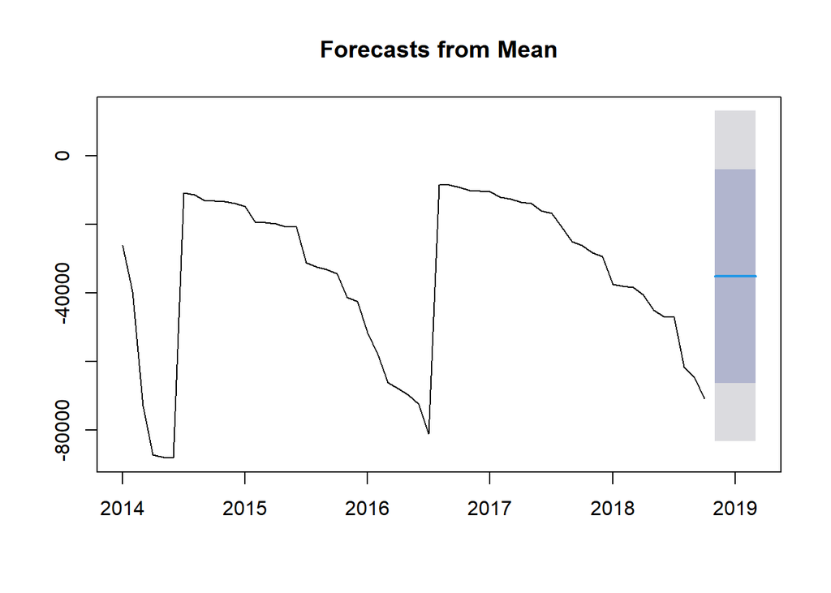

```r
plot(mean_forecast)
```

```r
accuracy(mean_forecast)
```

```
##                         ME     RMSE      MAE       MPE     MAPE      MASE
## Training set -6.281565e-13 23660.24 19808.96 -61.15191 90.36986 0.5479798
##                   ACF1
## Training set 0.7689376
```

## Step 2 Random Walk

```r
library(forecast)

Data_ts<-- ts(data$Sales, start=c(2014, 1), frequency=12)
attributes(Data_ts)
```

```
## $tsp
## [1] 2014.00 2018.75   12.00
##
## $class
## [1] "ts"
```

```r
forecast_period <- 5  # Number of periods to forecast
rwf_forecast <- rwf(Data_ts, h = forecast_period)

print(rwf_forecast)
```

```
##          Point Forecast      Lo 80     Hi 80     Lo 95      Hi 95
## Nov 2018         -70918  -90744.61 -51091.39 -101240.2 -40595.813
## Dec 2018         -70918  -98957.06 -42878.94 -113800.0 -28035.951
## Jan 2019         -70918 -105258.70 -36577.30 -123437.6 -18398.431
## Feb 2019         -70918 -110571.23 -31264.77 -131562.4 -10273.625
## Mar 2019         -70918 -115251.65 -26584.35 -138720.5  -3115.528
```

[figure not shown]

```r
plot(rwf_forecast, main="Randomwalk forecast Sales-Superstore", ylab="Sales/Monthly $", xlab="forecast sales 1/2019-5/2019")
lines(rwf_forecast$mean,col="black")
```

```r
accuracy(rwf_forecast)
```

```
##                     ME     RMSE      MAE       MPE     MAPE      MASE
## Training set -786.2807 15470.79 6052.189 -19.30196 36.12719 0.1674231
##                    ACF1
## Training set 0.04095451
```

#Naive Model

[figure not shown]

```r
naive_forecast <- naive(Data_ts,6)
plot(naive_forecast,main="6 months forecast Sales-Superstore",ylab="Sales/Monthly $",xlab = "forecast sales 1/2019-6/2019")
```

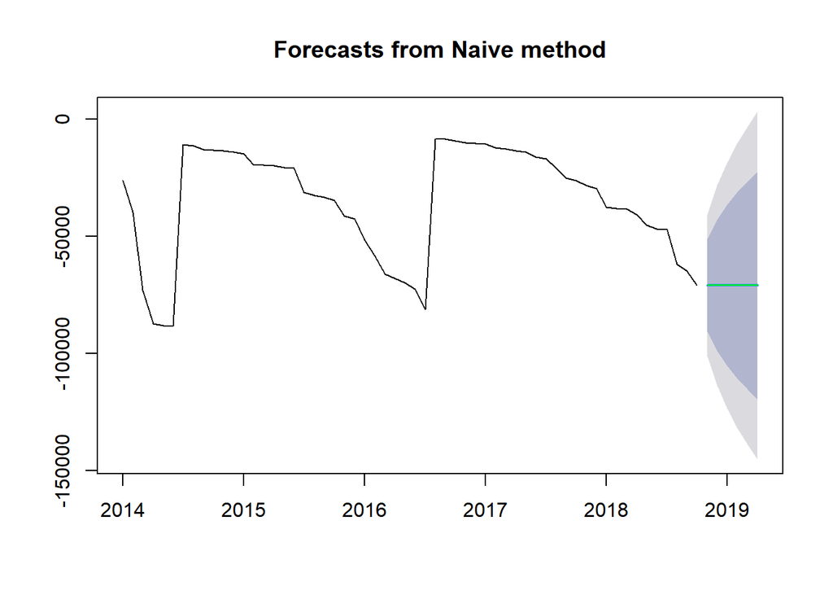

```r
plot(naive_forecast )
lines(naive_forecast$mean,col="Green")
```

```r
accuracy(naive_forecast)
```

```
##                     ME     RMSE      MAE       MPE     MAPE      MASE
## Training set -786.2807 15470.79 6052.189 -19.30196 36.12719 0.1674231
##                    ACF1
## Training set 0.04095451
```

#Seasonal Naive

```r
snaive_forecast <- snaive(Data_ts,6)
print(snaive_forecast)
```

```
##          Point Forecast     Lo 80     Hi 80     Lo 95    Hi 95
## Nov 2018       -28392.0 -78885.09 22101.085 -105614.5 48830.51
## Dec 2018       -29493.0 -79986.09 21000.085 -106715.5 47729.51
## Jan 2019       -37437.6 -87930.69 13055.485 -114660.1 39784.91
## Feb 2019       -38086.4 -88579.49 12406.685 -115308.9 39136.11
## Mar 2019       -38380.0 -88873.09 12113.085 -115602.5 38842.51
## Apr 2019       -40636.8 -91129.89  9856.285 -117859.3 36585.71
```

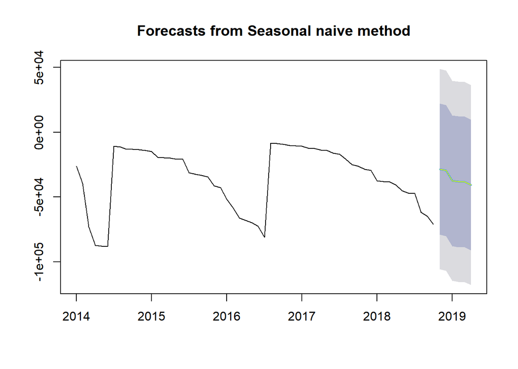

```r
plot(snaive_forecast)
lines(snaive_forecast$mean,col="yellow")
```

```r
accuracy(snaive_forecast)
```

```
##                     ME     RMSE      MAE       MPE     MAPE MASE      ACF1
## Training set -1546.917 39399.96 36149.08 -82.43061 163.0358    1 0.8375852
```

#The graph displays forecasts made using the Seasonal Naive method with a horizon (H) of 6 months. Ponit data is sales forecast value for each future month.For example, in Nov 2018, the forecasted value is -28392.0.the 80% prediction interval. It suggests there’s an 80% probability the actual values will fall within this range.For Nov 2018, the range is between -78885.09 (Lo 80) and 22101.085 (Hi 80).Lo 95 and Hi 95 :This depicts the 95% prediction interval, implying a 95% probability that the true value lies within this range.For Nov 2018, the interval is between -105614.5 (Lo 95) and 48830.51 (Hi 95).

#Plot all of these together

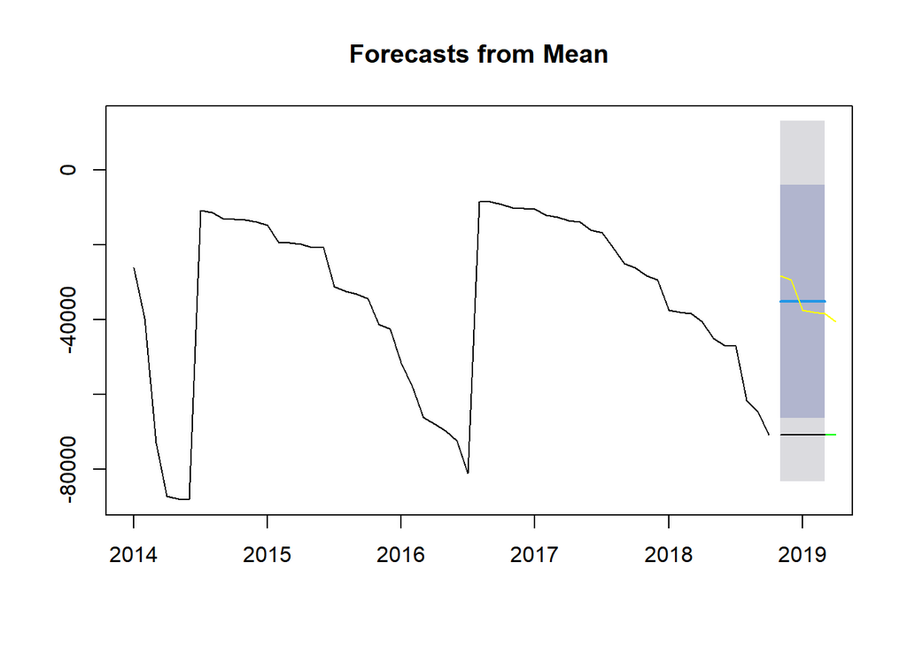

```r
plot(mean_forecast)
lines(naive_forecast$mean,col="green")
lines(snaive_forecast$mean,col="yellow")
lines(rwf_forecast$mean,col="black")
```

#The graph displays a time series forecast using mean . the “Point Forecast,” representing the predicted sales forecast for 2019 is consistently -35136.93.. The “Lo 80” and “Hi 80” values form an 80% prediction interval, suggesting there’s an 80% chance actual values lie within this range. Similarly, “Lo 95” and “Hi 95” define a wider 95% prediction interval, showing greater uncertainty but higher confidence in the predicted range.

# moving averages

```r
sales_data <- data$Sales

MA5_forecast <- ma(sales_data, order=5)
MA9_forecast <- ma(sales_data, order=9)

print(MA5_forecast)
```

```
## Time Series:
## Start = 1
## End = 58
## Frequency = 1
##  [1]       NA       NA 62764.00 75188.00 69432.80 57105.60 42265.60 27307.20
##  [9] 12335.20 12962.40 13659.60 14947.60 16213.20 17525.20 18873.20 20050.40
## [17] 22392.80 24981.60 27650.40 30411.20 34520.00 36809.60 40633.60 45603.20
## [25] 51924.80 57265.40 62687.80 66873.80 71469.00 59927.72 48026.80 35921.20
## [33] 23447.04  9294.80  9725.36 10461.04 11139.84 11837.60 12549.04 13651.76
## [41] 14584.82 16232.42 18524.26 20986.66 23450.66 25984.84 29309.16 31921.00
## [49] 34357.80 36806.76 39931.20 41821.68 43611.92 48289.92 53098.08 58258.64
## [57]       NA       NA
```

```r
print(MA9_forecast)
```

```
## Time Series:
## Start = 1
## End = 58
## Frequency = 1
##  [1]       NA       NA       NA       NA 48580.89 47139.56 44224.00 37664.00
##  [9] 29625.11 22016.22 14375.78 15386.44 16423.78 17283.33 19286.00 21401.56
## [17] 23546.44 25730.22 28156.89 30728.44 34239.56 38396.44 43438.22 47530.56
## [25] 51676.33 56030.33 61206.33 57553.62 53762.33 49058.33 43721.36 37523.00
## [33] 31142.49 24747.47 18095.02 10592.80 11201.51 12045.24 12893.92 14086.90
## [41] 15720.28 17457.79 19261.70 21141.14 23793.32 26482.48 28961.14 31607.22
## [49] 34307.13 36736.33 39052.07 42760.73 46670.13 50390.18       NA       NA
## [57]       NA       NA
```

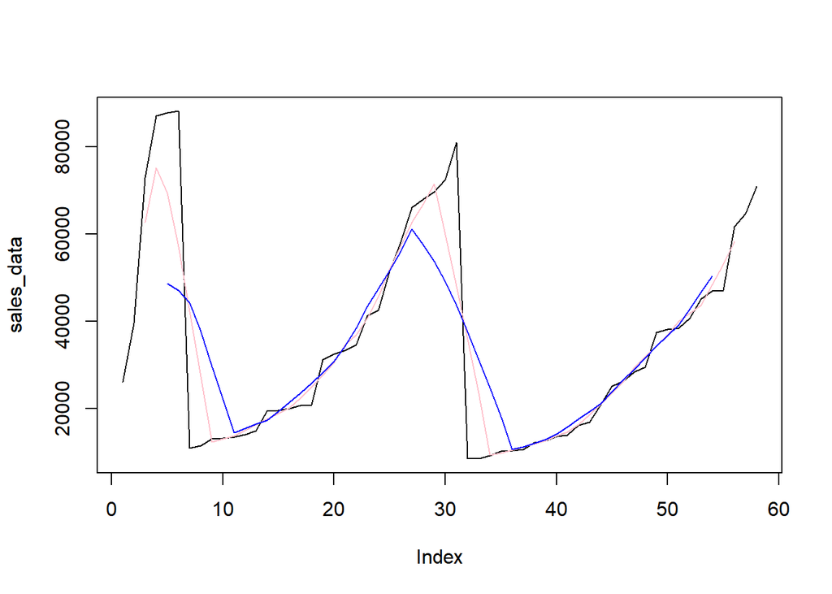

```r
if (length(sales_data) == length(MA5_forecast) && length(sales_data) == length(MA9_forecast)) {
  plot(sales_data, type="l") # Use the extracted sales_data
  lines(MA5_forecast, col="Pink")
  lines(MA9_forecast, col="Blue")
} else {
  cat("The lengths or data types do not match, please check the data.\n")
}
```

```r
MA5_forecast <- na.omit(MA5_forecast)
MA9_forecast <- na.omit(MA9_forecast)


# Aligning MA5 with sales data
MA5_forecast_clean <- na.omit(MA5_forecast)
sales_data_MA5 <- tail(sales_data, length(MA5_forecast_clean))



# Aligning MA9 with sales data
MA9_forecast_clean <- na.omit(MA9_forecast)
sales_data_MA9 <- tail(sales_data, length(MA9_forecast_clean))



accuracy(MA5_forecast_clean, sales_data_MA5)
```

```
##                 ME     RMSE      MAE       MPE    MAPE
## Test set -91.91704 16325.09 10240.33 -38.79166 64.1816
```

```r
accuracy(MA9_forecast_clean, sales_data_MA9)
```

```
##               ME     RMSE      MAE       MPE    MAPE
## Test set 577.232 19196.89 15591.16 -50.89209 90.6618
```

```r
#Hotls Winter Forecast
sales_data <- ts(data$Sales, start=c(2014, 1), frequency=12)
hw_model <- HoltWinters(sales_data)
print(hw_model)
```

```
## Holt-Winters exponential smoothing with trend and additive seasonal component.
##
## Call:
## HoltWinters(x = sales_data)
##
## Smoothing parameters:
##  alpha: 0.9182246
##  beta : 0.01014717
##  gamma: 1
##
## Coefficients:
##            [,1]
## a    78267.4857
## b     -497.8598
## s1   -1226.4765
## s2    4476.0320
## s3    7315.0209
## s4   11195.8622
## s5   10997.6059
## s6    9677.6656
## s7    8473.9973
## s8    6381.3853
## s9   -9710.7217
## s10 -18383.8917
## s11 -13051.0531
## s12  -7349.4857
```

```r
hw_forecast <- forecast(hw_model)

#SSE Forecast
sse <- sum(hw_model$residuals^2)
cat("Sum of Squared Errors (SSE):", sse, "\n")
```

```
## Sum of Squared Errors (SSE): 0
```

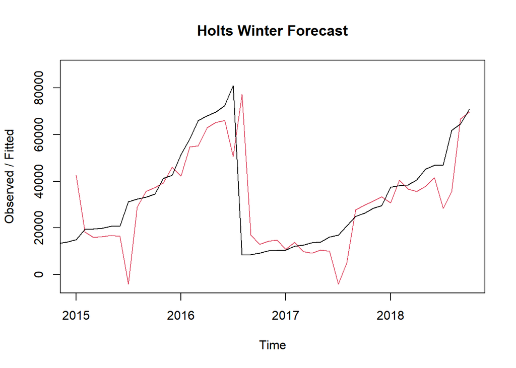

```r
plot(hw_model, main="Holts Winter Forecast")
```

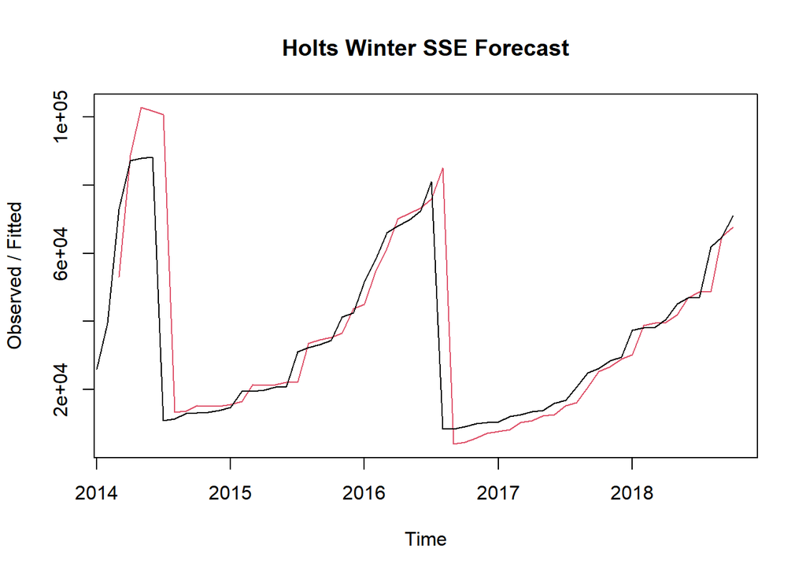

```r
SSE_Trend <- HoltWinters(sales_data, gamma=FALSE)
plot(SSE_Trend, main="Holts Winter SSE Forecast")
```

```r
print(SSE_Trend)
```

```
## Holt-Winters exponential smoothing with trend and without seasonal component.
##
## Call:
## HoltWinters(x = sales_data, gamma = FALSE)
##
## Smoothing parameters:
##  alpha: 1
##  beta : 0.1093785
##  gamma: FALSE
##
## Coefficients:
##       [,1]
## a 70918.00
## b  3342.46
```

```r
SSE_Trend_forecast <- forecast(SSE_Trend) # You should create a different forecast object


accuracy(hw_forecast)
```

```
##                    ME     RMSE     MAE      MPE     MAPE      MASE       ACF1
## Training set 2338.307 14912.43 8673.98 -12.0117 45.76042 0.2399502 -0.0086229
```

```r
accuracy(SSE_Trend_forecast)
```

```
##                    ME     RMSE      MAE       MPE     MAPE      MASE       ACF1
## Training set -1658.32 16592.46 6328.499 -24.40461 43.43986 0.1750667 0.05081545
```